# Cechy jakościowe

pogRomcy danych

sezon 1 / odcinek 12  
[Przemysław Biecek @ Uniwersytet Warszawski](http://biecek.pl/)  
Naciśnij `A` by zamienić slajdy na ciągły tekst.  
Naciśnij `T` by wyświetlić spis treści.

Analizując dane będziemy spotykać się z różnymi rodzajami zmiennych. Bardzo często będą to cechy jakościowe, w niektórych sytuacjach będziemy chcieli cechę ilościową przekształcić w jakościową.

W tym odcinku nauczymy się:

- jakie zmienne / cechy określa się terminem *cechy jakościowe*,
- jakie podstawowe operacje można wykonywać na cechach jakościowych,
- jak podsumowywać / opisywać cechy jakościowe.

Do ilustracji tych zagadnień wykorzystamy dwa zbiory danych. Pierwszy, mały zbiór danych, to `koty_ptaki` a drugi, znacznie większy, to `auta2012`, oba dostępne w pakiecie `PogromcyDanych`.

# Co to znaczy: cecha jakościowa

Cechy jakościowe to takie, które opisują przynależność do grup. Z tego powodu często stosuje się też nazwę *zmienna grupująca*. A ponieważ w programie R taką zmienną oznacza się terminem `factor`, to w języku polskim spotyka się kalkę *zmienna faktor*. Inną nazwą, stosowaną często przez programistów, jest *zmienna czynnikowa*.

Określając zmienną jakościową warto wskazać o jakich grupach mówimy, przykładami zmiennych jakościowych są np. wykształcenie (grupy: podstawowe, średnie, wyższe), płeć (grupy: kobieta, mężczyzna), kraj zamieszkania (grupy: Polska, …).

Zmienna jakościowa może być opisana liczbami, jeżeli jednak te liczby nie oznaczają ilości czy wielkości to taka zmienna jest w istocie zmienną jakościową. Przykładowo pierwsze dwie cyfry kodu pocztowego mogą być zmienną jakościową, ocenę szkolną można traktować jako zmienną jakościową (można też jako ilościową zależnie od kontekstu), podobnie liczbę drzwi samochodu, jeżeli chcemy jej użyć do pogrupowania samochodów na 3 i 5 drzwiowe, potraktujemy jako cechę jakościową.

Jakkolwiek zmienne jakościowe mogą bardzo różnić się liczbą grup oraz rodzajem grup, można na nich wykonywać kilka wspólnych operacji. Przyjrzyjmy się im.

# Wczytanie danych

Dane od których rozpoczniemy przykłady to `koty_ptaki` z pakietu `PogromcyDanych`. Aby te dane wczytać, wystarczy włączyć ten pakiet - instrukcja jak to zrobić znajduje się w odcinku 2.

Włączmy pakiet i użyjmy funkcji `head()` by wyświetlić pierwsze sześć wierszy. Które z tych zmiennych to zmienne jakościowe?

```r
library(PogromcyDanych)
head(koty_ptaki)
```

```
##   gatunek waga dlugosc predkosc habitat zywotnosc druzyna
## 1  Tygrys  300     2.5       60    Azja        25     Kot
## 2     Lew  200     2.0       80  Afryka        29     Kot
## 3  Jaguar  100     1.7       90 Ameryka        15     Kot
## 4    Puma   80     1.7       70 Ameryka        13     Kot
## 5 Leopard   70     1.4       85    Azja        21     Kot
## 6  Gepard   60     1.4      115  Afryka        12     Kot
```

Każdy wiersz opisuje jeden gatunek. Zmienne jakościowe to w poniższym przypadku wszystkie te, które nie są liczbowymi, a więc *gatunek*, *habitat* i *druzyna*.

# Cechy jakościowe

Przyjrzyjmy się dwóm z tych zmiennych - *gatunek* i *druzyna*.

```r
koty_ptaki$gatunek
```

```
##  [1] Tygrys         Lew            Jaguar         Puma
##  [5] Leopard        Gepard         Irbis          Jerzyk
##  [9] Strus          Orzel przedni  Sokol wedrowny Sokol norweski
## [13] Albatros
## 13 Levels: Albatros Gepard Irbis Jaguar Jerzyk Leopard ... Tygrys
```

```r
koty_ptaki$druzyna
```

```
##  [1] Kot  Kot  Kot  Kot  Kot  Kot  Kot  Ptak Ptak Ptak Ptak Ptak Ptak
## Levels: Kot Ptak
```

Gdy te zmienne są wyświetlane, poza wartościami dodatkowo wyświetlany jest zbiór wszystkich możliwych wartości. Ten zbiór nazywa się najczęściej poziomami zmiennej jakościowej lub słownikiem zmiennej.

Dwie podstawowe operacje na zmiennych jakościowych to odczytywanie poziomów zmiennej, co można zrobić funkcją `levels()`, oraz wyznaczanie liczebności poszczególnych poziomów, co można wykonać funkcją `table()`.

To czy dana zmienna jest zmienną jakościową czy ilościową można sprawdzić używając funkcji `class()`. Jeżeli wynikiem jest napis `factor` to mamy do czynienia ze zmienną jakościową. Jeżeli wynikiem jest `integer` lub `numeric` to mamy do czynienia ze zmienną ilościową.

```r
class(koty_ptaki$druzyna)
```

```
## [1] "factor"
```

```r
class(koty_ptaki$predkosc)
```

```
## [1] "integer"
```

```r
class(koty_ptaki$dlugosc)
```

```
## [1] "numeric"
```

# Cechy jakościowe

Przykładowo dla dwóch wybranych zmiennych ze zbioru `koty_ptaki` otrzymujemy takie wyniki dla obu funkcji.

Wynikiem funkcji `levels()` jest wektor napisów - poziomów zmiennej jakościowej.

```r
levels(koty_ptaki$gatunek)
```

```
##  [1] "Albatros"       "Gepard"         "Irbis"          "Jaguar"
##  [5] "Jerzyk"         "Leopard"        "Lew"            "Orzel przedni"
##  [9] "Puma"           "Sokol norweski" "Sokol wedrowny" "Strus"
## [13] "Tygrys"
```

```r
levels(koty_ptaki$druzyna)
```

```
## [1] "Kot"  "Ptak"
```

Wynikiem funkcji `table()` jest wektor liczebności każdego czynnika.

```r
table(koty_ptaki$gatunek)
```

```
##
##       Albatros         Gepard          Irbis         Jaguar         Jerzyk
##              1              1              1              1              1
##        Leopard            Lew  Orzel przedni           Puma Sokol norweski
##              1              1              1              1              1
## Sokol wedrowny          Strus         Tygrys
##              1              1              1
```

```r
table(koty_ptaki$druzyna)
```

```
##
##  Kot Ptak
##    7    6
```

Obie zmienne znacznie się różnią. Drużyna występuje tylko w dwóch wartościach a gatunek w trzynastu (każdy wiersz to inna wartość).

# Wczytanie danych

Zbiór danych `koty_ptaki` składa się z 13 wierszy. Można cały ten zbiór danych wyświetlić na ekranie. Nie zawsze potrzebujemy więc specjalnych statystyk opisowych by zrozumieć co się dzieje w takich małych zbiorach danych.

Dlatego dalsze ćwiczenia ze zmiennymi jakościowymi przeprowadzimy na znaczenie większym zbiorze danych `auta2012` o ponad 200 tysiącach wierszy, który również znajduje się w pakiecie `PogromcyDanych`.

Opis tego zbioru danych znaleźć można w odcinku http://pogromcydanych.icm.edu.pl/materials/1_przetwarzanie/0_dane.html

Wczytajmy ten zbiór danych i przyjrzyjmy się dwóm pierwszym wierszom.

```r
library(PogromcyDanych)
head(auta2012, 2)
```

```
##    Cena Waluta Cena.w.PLN Brutto.netto  KM  kW      Marka     Model Wersja
## 1 49900    PLN      49900       brutto 140 103        Kia    Carens
## 2 88000    PLN      88000       brutto 156 115 Mitsubishi Outlander
##   Liczba.drzwi Pojemnosc.skokowa Przebieg.w.km          Rodzaj.paliwa
## 1          4/5              1991         41000 olej napedowy (diesel)
## 2          4/5              2179         46500 olej napedowy (diesel)
##   Rok.produkcji Kolor Kraj.aktualnej.rejestracji Kraj.pochodzenia
## 1          2008                           Polska
## 2          2008                           Polska
##   Pojazd.uszkodzony Skrzynia.biegow Status.pojazdu.sprowadzonego
## 1                          manualna
## 2                          manualna
##                                                                                                                                                                                Wyposazenie.dodatkowe
## 1                         ABS, el. lusterka, klimatyzacja, alufelgi, centralny zamek, autoalarm, poduszka powietrzna, radio / CD, wspomaganie kierownicy, immobiliser, komputer, przyciemniane szyby
## 2 ABS, 4x4, el. lusterka, klimatyzacja, skorzana tapicerka, alufelgi, centralny zamek, poduszka powietrzna, radio / CD, wspomaganie kierownicy, immobiliser, komputer, tempomat, przyciemniane szyby
```

Które z tych zmiennych to zmienne jakościowe?

Gdy w zbiorze danych jest wiele kolumn, to często wygodnie na pierwsze wiersze spojrzeć poprzez funkcję `glimpse()` która kolejne kolumny ze zbioru danych przedstawia jedna pod drugą.

```r
glimpse(auta2012)
```

```
## Observations: 207602
## Variables:
## $ Cena                         (dbl) 49900, 88000, 86000, 25900, 55900...
## $ Waluta                       (fctr) PLN, PLN, PLN, PLN, PLN, PLN, PL...
## $ Cena.w.PLN                   (dbl) 49900, 88000, 86000, 25900, 55900...
## $ Brutto.netto                 (fctr) brutto, brutto, brutto, brutto, ...
## $ KM                           (dbl) 140, 156, 150, 163, NA, 150, 115,...
## $ kW                           (dbl) 103, 115, 110, 120, NA, 110, 85, ...
## $ Marka                        (fctr) Kia, Mitsubishi, Chevrolet, Volv...
## $ Model                        (fctr) Carens, Outlander, Captiva, S80,...
## $ Wersja                       (fctr) , , , , , , , Mk2, , , Mk4, IV, ...
## $ Liczba.drzwi                 (fctr) 4/5, 4/5, 4/5, 4/5, 4/5, 4/5, 4/...
## $ Pojemnosc.skokowa            (dbl) 1991, 2179, 1996, 2400, 2200, 220...
## $ Przebieg.w.km                (dbl) 41000, 46500, 8000, 200000, 16940...
## $ Rodzaj.paliwa                (fctr) olej napedowy (diesel), olej nap...
## $ Rok.produkcji                (dbl) 2008, 2008, 2009, 2003, 2007, 200...
## $ Kolor                        (fctr) , , , srebrny-metallic, bialy, b...
## $ Kraj.aktualnej.rejestracji   (fctr) Polska, Polska, Polska, Polska, ...
## $ Kraj.pochodzenia             (fctr) , , , Wlochy, , , Polska, Polska...
## $ Pojazd.uszkodzony            (fctr) , , , , , , , , , , , , , , , , ...
## $ Skrzynia.biegow              (fctr) manualna, manualna, manualna, ma...
## $ Status.pojazdu.sprowadzonego (fctr) , , , sprowadzony / zarejestrowa...
## $ Wyposazenie.dodatkowe        (fctr) ABS, el. lusterka, klimatyzacja,...
```

# Statystyki opisowe

Przyjrzyjmy się teraz takim cechom jak `Waluta` lub `Marka`. Cechy te są opisane przez wartości z określonej listy możliwości. Dla cechy `Waluta` lista możliwości to `levels(auta2012$Waluta)`=CHF, CZK, EEK, EUR, GBP, HUF, PLN, USD.

Dla cech jakościowych możemy wykonać kilka operacji. Jedną z nich jest wyświetlenie listy możliwych wartości. Taką listę nazywa się często słownikiem (spisem możliwych wartości).

Listę możliwych wartości dla zmiennej jakościowej można wyznaczyć funkcją `levels()`.

```r
levels(auta2012$Waluta)
```

```
## [1] "CHF" "CZK" "EEK" "EUR" "GBP" "HUF" "PLN" "USD"
```

Zmienne jakościowe często opisuje się tablicą liczebności, a więc informacją ile razy wystąpiła każda z wartości ze słownika. Tablicę liczebności można wyznaczyć funkcją `table()` lub `summary()`. Jeżeli w zmiennej jakościowej występują wartości brakujące, to funkcja `summary()` też napisze ile ich jest (funkcja `table()` domyślnie tego nie robi, można takie zachowanie wymusić dodając argument `useNA = "always"`).

```r
table(auta2012$Waluta)
```

```
##
##    CHF    CZK    EEK    EUR    GBP    HUF    PLN    USD
##      5  19070      2   5407      5    611 181844    658
```

```r
summary(auta2012$Waluta)
```

```
##    CHF    CZK    EEK    EUR    GBP    HUF    PLN    USD
##      5  19070      2   5407      5    611 181844    658
```

# Zadania:

- Ile zmiennych w zbiorze danych `auta2012` to zmienne jakościowe?
- Zmienna `Liczba.drzwi` przyjmuje wartości `2/3` i `4/5`. Zachowuje się ona jako zmienna jakościowa. Jednak można uznać, że liczba drzwi to cecha ilościowa, ponieważ opisuje *ilość* drzwi w samochodzie. Jak wyjaśnić tę dualność?

Przykładowe odpowiedzi znajdują się na stronie http://pogromcydanych.icm.edu.pl/materials/1_przetwarzanie/9_zadania.html

# Procenty

W pewnych sytuacjach, zamiast posługiwać się tablicą liczebności, wygodniej jest posługiwać się tabelą z procentami.

Ale jak te procenty policzyć?

Można to zrobić na kilka sposobów. Funkcja `prop.table()` dzieli wartości tabeli liczebności przez sumę liczebności, a więc zamienia liczebności na frakcje (frakcje czyli procenty, części całości). Przypiszmy wynik funkcji `table()` do jakiejś zmiennej, np. o nazwie `waluty` (nazwa może być dowolna, musimy jej jednak konsekwentnie używać w dalszych przykładach). Następnie tak otrzymaną tabelę liczebności zamieniamy na frakcje.

W poniższym przykładzie, instrukcję przypisania wyniku obejmujemy napisami, po to by jej wynik był wyświetlony. Bez nawiasów wynik funkcji `table()` nie zostałby wyświetlony, a jedynie przypisany do zmiennej `waluty`.

```r
(waluty <- table(auta2012$Waluta))
```

```
##
##    CHF    CZK    EEK    EUR    GBP    HUF    PLN    USD
##      5  19070      2   5407      5    611 181844    658
```

```r
prop.table(waluty)
```

```
##
##          CHF          CZK          EEK          EUR          GBP
## 2.408455e-05 9.185846e-02 9.633819e-06 2.604503e-02 2.408455e-05
##          HUF          PLN          USD
## 2.943132e-03 8.759261e-01 3.169526e-03
```

# Procenty

Funkcja `prop.table()` wyznacza frakcje, ale nie wyglądają one zbyt czytelnie dla człowieka. Wygodniej by było wypisać procenty. I to nie byle jakie procenty, ale procenty które są ładnie sformatowane, np. wyświetlone z dokładnością do jednego miejsca dziesiętnego po przecinku.

Aby zamienić frakcje na procenty, wystarczy je przemnożyć przez 100, a aby wynik przedstawić z dokładnością do jednego miejsca po przecinku wykorzystamy funkcję `round()`, która zaokrągla liczby do wskazanej liczby miejsc po kropce dziesiętnej.

```r
waluty <- table(auta2012$Waluta)
(frakcje <- prop.table(waluty))
```

```
##
##          CHF          CZK          EEK          EUR          GBP
## 2.408455e-05 9.185846e-02 9.633819e-06 2.604503e-02 2.408455e-05
##          HUF          PLN          USD
## 2.943132e-03 8.759261e-01 3.169526e-03
```

```r
(procenty <- 100*frakcje)
```

```
##
##          CHF          CZK          EEK          EUR          GBP
## 2.408455e-03 9.185846e+00 9.633819e-04 2.604503e+00 2.408455e-03
##          HUF          PLN          USD
## 2.943132e-01 8.759261e+01 3.169526e-01
```

```r
round(procenty, digits = 1)
```

```
##
##  CHF  CZK  EEK  EUR  GBP  HUF  PLN  USD
##  0.0  9.2  0.0  2.6  0.0  0.3 87.6  0.3
```

Wszystkie przedstawione powyżej operacje działają i na pojedynczych wartościach jak i na wektorach. Przykładowo operacja `100*frakcje` wymnaża liczbę `100` z każdym elementem wektora `frakcje` i wynikiem tej operacji jest wektor. Nie w każdym języku programowania można mieć takie mieszane operacje mnożenia wektorów i pojedynczych liczb. W programie R jest to możliwe ponieważ od podstaw wszystkie operacje były planowane jako operacje wektorowe i nawet pojedyncze wartości są w rzeczywistości wektorami o długości 1. Wykonując operacje na dwóch wektorach krótszy jest powtarzany tak długo aż długością zrówna się z dłuższym.

# Procenty posortowane

Mamy już procenty. Aby dodatkowo zwiększyć czytelność tej formy prezentacji warto te procenty posortować rosnąco lub malejąco.

Nawet dla ośmiu liczb, jeżeli każda z nich jest opisana przez wiele cyfr, czasem w gąszczu cyfr trudno nawet dostrzec, która jest największa.

Do sortowania można wykorzystać funkcję `sort()`. Dodając argument `decreasing = TRUE` powodujemy, że wartości będą uporządkowane malejąco.

```r
zaokragloneProcenty <- round(procenty,1)
sort(zaokragloneProcenty)
```

```
##
##  CHF  EEK  GBP  HUF  USD  EUR  CZK  PLN
##  0.0  0.0  0.0  0.3  0.3  2.6  9.2 87.6
```

```r
sort(zaokragloneProcenty, decreasing = TRUE)
```

```
##
##  PLN  CZK  EUR  HUF  USD  CHF  EEK  GBP
## 87.6  9.2  2.6  0.3  0.3  0.0  0.0  0.0
```

# Procenty posortowane

Wartości w wektorze można posortować też na kilka innych sposobów. Bardziej skomplikowanym, ale pozwalającym na omówienie bardziej zaawansowanych przykładów indeksowania jest funkcja `order()`.

Wynikiem funkcji `order()` są indeksy elementów w wektorze, które tworzą ciąg rosnący. Więcej informacji o tej funkcji znaleźć można na sladzie *Sortowanie przez indeksowanie* w odcinku 7.

```r
order(zaokragloneProcenty)
```

```
## [1] 1 3 5 6 8 4 2 7
```

Jeżeli wektor `zaokragloneProcenty` będziemy czytać w kolejności, pierwszy element, trzeci, piąty, szósty, ósmy, czwarty, drugi i siódmy, to otrzymamy posortowany ciąg.

Możemy więc wynik tej funkcji wykorzystać do indeksowania oryginalnego zbioru danych, i w ten sposób posortować cały wektor.

```r
kolejnoscPosortowanych <- order(zaokragloneProcenty)
zaokragloneProcenty[kolejnoscPosortowanych]
```

```
##
##  CHF  EEK  GBP  HUF  USD  EUR  CZK  PLN
##  0.0  0.0  0.0  0.3  0.3  2.6  9.2 87.6
```

Funkcja `rev()` odwraca kolejność elementów w wektorze, możemy jej użyć by posortowac wartości malejąco.

```r
zaokragloneProcenty[rev(kolejnoscPosortowanych)]
```

```
##
##  PLN  CZK  EUR  USD  HUF  GBP  EEK  CHF
## 87.6  9.2  2.6  0.3  0.3  0.0  0.0  0.0
```

A jak sprawdzić, na których pozycjach występują trzy najmniejsze wartości?

```r
kolejnoscPosortowanych[1:3]
```

```
## [1] 1 3 5
```

# Zadania:

- Cecha `Marka` opisuje markę samochodu. Sprawdź, która marka jest najpopularniejsza.
- Cecha `Rodzaj.paliwa` opisuje rodzaj paliwa wykorzystywanego przez auto. Czy jest to benzyna, olej, gaz? Sprawdź jaki procent samochodów jest napędzana na benzynę.

Przykładowe odpowiedzi znajdują się na stronie http://pogromcydanych.icm.edu.pl/materials/1_przetwarzanie/9_zadania.html

# Graficzne statystyki opisowe

Tabele liczebności są proste w interpretacji. Podobnie jednak jak w innych przypadkach, graficzne przedstawienie liczb pozwala na łatwiejsze dostrzeżenie co się dzieje w danych. Koniec końców, w tabeli liczb łatwo pomylić się nawet gdy chodzi o liczbę cyfr w liczbie. Na wykresie takie wartości natychmiast rzucają się w oczy.

Zazwyczaj tabele liczebności przedstawia się za pomocą wykresów słupkowych. Wykresy słupkowe można wykonać np. funkcją `barplot()`.

```r
(waluty <- table(auta2012$Waluta))
```

```
##
##    CHF    CZK    EEK    EUR    GBP    HUF    PLN    USD
##      5  19070      2   5407      5    611 181844    658
```

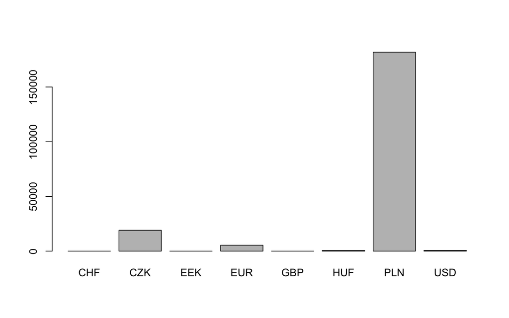

```r
barplot(waluty)
```

# Graficzne statystyki opisowe

Jeżeli chcemy, by słupki były przedstawiane poziomo, do funkcji `barplot()` można dodać argument `horiz = TRUE`.

Domyślnie wartości są uporządkowane alfabetycznie. Nie zawsze jednak taka kolejność ma sens. W tym przypadku rozsądniej jest posortować dane malejąco, co można wykonać z użyciem funkcji `sort()`.

Argument `las=1` powoduje, że oś OY ma etykiety ustawione poziomo.

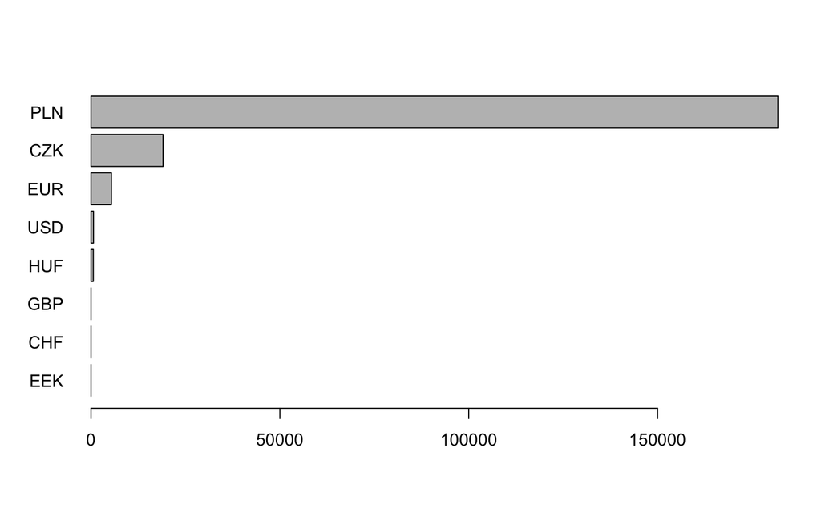

```r
posortowaneWaluty <- sort(waluty)
barplot(posortowaneWaluty, horiz = TRUE, las=1)
```

# Zadania:

- Przedstaw graficznie tabelę liczebności dla zmiennej `Kraj.pochodzenia`. Wypróbuj wykres pionowy i poziomy. Aby obrócić kierunek etykiet na osiach dodaj do funkcji `barplot()` argument `las=1`.

Przykładowe odpowiedzi znajdują się na stronie http://pogromcydanych.icm.edu.pl/materials/1_przetwarzanie/9_zadania.html

# Napisy czy czynniki?

Z wyglądu, cechy jakościowe (czynniki) przypominają cechy napisowe. Jednak pod spodem, ich reprezentacja jest zupełnie inna. Czynniki nie są pamiętane jako napisy, ale jako para - wektor liczb i słownik, określający, który napis odpowiada, której liczbie.

Na napisach zazwyczaj wykonuje się inne operacje niż na zmiennych jakościowych, może się więc tak zdarzyć, że celowo chcemy jakieś dane odczytać jako napisy. Ale gdy dane są wczytywane z pliku tekstowego w którym są napisy, domyślnie traktowane są jako czynniki.

W poniższym przykładzie takie zmienne jak `gatunek` i `habitat` są wczytywane jako zmienna klasy `factor`. Efektem ubocznym jest sposób wyświetlania wyników np. przez zmienną `cat()`. Dla zmiennej czynnikowej, ta funkcja na ekranie wypisze liczby a nie wartości napisowe.

```r
koty_ptaki <- read.table("http://biecek.pl/MOOC/dane/koty_ptaki.csv",
          sep=";", dec=",", header=TRUE)
str(koty_ptaki)
```

```
## 'data.frame':    13 obs. of  7 variables:
##  $ gatunek  : Factor w/ 13 levels "Albatros","Gepard",..: 13 7 4 9 6 2 3 5 12 8 ...
##  $ waga     : num  300 200 100 80 70 60 50 0.05 150 5 ...
##  $ dlugosc  : num  2.5 2 1.7 1.7 1.4 1.4 1.3 0.2 2.5 0.9 ...
##  $ predkosc : int  60 80 90 70 85 115 65 170 70 160 ...
##  $ habitat  : Factor w/ 6 levels "Afryka","Ameryka",..: 3 1 2 2 3 1 3 4 1 5 ...
##  $ zywotnosc: int  25 29 15 13 21 12 18 20 45 20 ...
##  $ druzyna  : Factor w/ 2 levels "Kot","Ptak": 1 1 1 1 1 1 1 2 2 2 ...
```

```r
class(koty_ptaki$gatunek)
```

```
## [1] "factor"
```

```r
cat(koty_ptaki$gatunek)
```

```
## 13 7 4 9 6 2 3 5 12 8 11 10 1
```

# Napisy czy czynniki?

Funkcja `read.table()` posiada argument `stringsAsFactors` określający w jaki sposób wczytywać kolumny z napisami. Ustawiwszy argument `stringsAsFactors=FALSE` wymuszamy wczytywanie danych jako zmienne napisowe.

Zauważmy jak teraz wygląda wynik funkcji `str()` i `cat()`.

```r
koty_ptaki <- read.table("http://biecek.pl/MOOC/dane/koty_ptaki.csv",
          sep=";", dec=",", header=TRUE, stringsAsFactors=FALSE)
str(koty_ptaki)
```

```
## 'data.frame':    13 obs. of  7 variables:
##  $ gatunek  : chr  "Tygrys" "Lew" "Jaguar" "Puma" ...
##  $ waga     : num  300 200 100 80 70 60 50 0.05 150 5 ...
##  $ dlugosc  : num  2.5 2 1.7 1.7 1.4 1.4 1.3 0.2 2.5 0.9 ...
##  $ predkosc : int  60 80 90 70 85 115 65 170 70 160 ...
##  $ habitat  : chr  "Azja" "Afryka" "Ameryka" "Ameryka" ...
##  $ zywotnosc: int  25 29 15 13 21 12 18 20 45 20 ...
##  $ druzyna  : chr  "Kot" "Kot" "Kot" "Kot" ...
```

```r
class(koty_ptaki$gatunek)
```

```
## [1] "character"
```

```r
cat(koty_ptaki$gatunek)
```

```
## Tygrys Lew Jaguar Puma Leopard Gepard Irbis Jerzyk Strus Orzel przedni Sokol wedrowny Sokol norweski Albatros
```

Tym razem kolumna `gatunek` została wczytana jako wektor napisów.

# Napisy czy czynniki?

Zmienne czynnikowe można konwertować na napisy funkcją `as.character()`.

Napisy można konwertować na zmienne czynnikowe funkcją `as.factor()`.

Przedstawmy działanie obu funkcji na przykładzie.

```r
czynniki <- as.factor(koty_ptaki$gatunek)
str(czynniki)
```

```
##  Factor w/ 13 levels "Albatros","Gepard",..: 13 7 4 9 6 2 3 5 12 8 ...
```

```r
napisy <- as.character(czynniki)
str(napisy)
```

```
##  chr [1:13] "Tygrys" "Lew" "Jaguar" "Puma" "Leopard" ...
```

# Tablice częstości

A co gdybyśmy chcieli przedstawić zależność pomiędzy dwoma zmiennymi jakościowymi? Można to zrobić używając funkcji `table()` (należy kolejne zmienne podawać jako kolejne argumenty). Przykładowe wywołanie dla dwóch zmiennych: Waluty i Kraju pochodzenia.

```r
table(auta2012$Kraj.pochodzenia, auta2012$Waluta)
```

Jednak wygodniej jest, takie tabele tworzyć używając funkcji `xtabs()`, która jest trochę wygodniejsza w pracy. Pierwszym argumentem tej funkcji jest formuła o składni `~ zmienna_1 + .. + zmienna_n`, t.j. rozpoczynająca się tyldą a następnie ze zmiennymi porozdzielanymi znakiem plusa. Drugim argumentem jest ramka danych, która powinna zawierać zmienne wymienione w formule.

Wynikiem jest tablica kontyngencji o tylu wymiarach, ile zmiennych występuje w formule.

Przykładowo, zestawiając ze sobą kraj pochodzenia oraz walutę w ogłoszeniu, otrzymujemy tablicę częstości o wymiarach 32 wiersze i 8 kolumn. Pierwszy wiersz tej tabeli odpowiada pustej wartości kraju pochodzenia, stąd brak nazwy w pierwszym wierszu.

```r
krajWaluta <- xtabs( ~ Kraj.pochodzenia + Waluta, auta2012)
krajWaluta
```

```
##                    Waluta
## Kraj.pochodzenia      CHF   CZK   EEK   EUR   GBP   HUF   PLN   USD
##                         0  5096     2  3619     4   543 79437   363
##   Austria               0   522     0    26     0     0  1439     0
##   Belgia                0   373     0   356     0     0  4984     0
##   Bulgaria              0     0     0     0     0     0     3     0
##   Chorwacja             0     0     0     0     0     0     1     0
##   Czechy                0  6099     0     0     0     0    62     0
##   Dania                 0    30     0   177     0     0   379     0
##   Estonia               0     1     0     0     0     0     6     0
##   Francja               0   987     0    37     0     0  7885     0
##   Grecja                0     0     0     0     0     0     4     0
##   Hiszpania             0    23     0    35     0     0   260     0
##   Holandia              0    81     0   145     0     0  3512     0
##   Irlandia              0     0     0     1     0     1    25     0
##   Islandia              0     0     0     0     0     0     3     0
##   Kanada                0     6     0     1     0     0    94     1
##   Litwa                 0     0     0     0     0     0    10     0
##   lotwa                 0     0     0     0     0     0     3     0
##   Luksemburg            0    13     0     0     0     0   308     0
##   Monako                0     0     0     0     0     0     2     0
##   Niemcy                1  4194     0   977     0     3 44701     1
##   Norwegia              0     0     0     0     0     0    12     0
##   Polska                1     1     0    12     0     0 31309     1
##   Rosja                 0     1     0     0     0     0    12     0
##   Rumunia               0     1     0     0     0     0     3     0
##   Slowacja              0    36     0     4     0     0    15     0
##   Stany Zjednoczone     0   150     0     4     0     1  2771   291
##   Szwajcaria            3   159     0     2     0     0  1348     1
##   Szwecja               0     7     0     0     0     0   148     0
##   Ukraina               0     1     0     0     0     0     5     0
##   Wegry                 0     0     0     0     0    63     3     0
##   Wielka Brytania       0    14     0     0     1     0  1208     0
##   Wlochy                0  1275     0    11     0     0  1892     0
```

Funkcja `prop.table()` liczy procenty (z drugim argumentem =1 liczy procenty w wierszach) a funkcja `round()` zaokrągla liczby (z dokładnością do tulu cyfr po kropce ile wskazano w drugim argumencie).

```r
round(prop.table(krajWaluta, 1), 3)
```

```
##                    Waluta
## Kraj.pochodzenia      CHF   CZK   EEK   EUR   GBP   HUF   PLN   USD
##                     0.000 0.057 0.000 0.041 0.000 0.006 0.892 0.004
##   Austria           0.000 0.263 0.000 0.013 0.000 0.000 0.724 0.000
##   Belgia            0.000 0.065 0.000 0.062 0.000 0.000 0.872 0.000
##   Bulgaria          0.000 0.000 0.000 0.000 0.000 0.000 1.000 0.000
##   Chorwacja         0.000 0.000 0.000 0.000 0.000 0.000 1.000 0.000
##   Czechy            0.000 0.990 0.000 0.000 0.000 0.000 0.010 0.000
##   Dania             0.000 0.051 0.000 0.302 0.000 0.000 0.647 0.000
##   Estonia           0.000 0.143 0.000 0.000 0.000 0.000 0.857 0.000
##   Francja           0.000 0.111 0.000 0.004 0.000 0.000 0.885 0.000
##   Grecja            0.000 0.000 0.000 0.000 0.000 0.000 1.000 0.000
##   Hiszpania         0.000 0.072 0.000 0.110 0.000 0.000 0.818 0.000
##   Holandia          0.000 0.022 0.000 0.039 0.000 0.000 0.940 0.000
##   Irlandia          0.000 0.000 0.000 0.037 0.000 0.037 0.926 0.000
##   Islandia          0.000 0.000 0.000 0.000 0.000 0.000 1.000 0.000
##   Kanada            0.000 0.059 0.000 0.010 0.000 0.000 0.922 0.010
##   Litwa             0.000 0.000 0.000 0.000 0.000 0.000 1.000 0.000
##   lotwa             0.000 0.000 0.000 0.000 0.000 0.000 1.000 0.000
##   Luksemburg        0.000 0.040 0.000 0.000 0.000 0.000 0.960 0.000
##   Monako            0.000 0.000 0.000 0.000 0.000 0.000 1.000 0.000
##   Niemcy            0.000 0.084 0.000 0.020 0.000 0.000 0.896 0.000
##   Norwegia          0.000 0.000 0.000 0.000 0.000 0.000 1.000 0.000
##   Polska            0.000 0.000 0.000 0.000 0.000 0.000 1.000 0.000
##   Rosja             0.000 0.077 0.000 0.000 0.000 0.000 0.923 0.000
##   Rumunia           0.000 0.250 0.000 0.000 0.000 0.000 0.750 0.000
##   Slowacja          0.000 0.655 0.000 0.073 0.000 0.000 0.273 0.000
##   Stany Zjednoczone 0.000 0.047 0.000 0.001 0.000 0.000 0.861 0.090
##   Szwajcaria        0.002 0.105 0.000 0.001 0.000 0.000 0.891 0.001
##   Szwecja           0.000 0.045 0.000 0.000 0.000 0.000 0.955 0.000
##   Ukraina           0.000 0.167 0.000 0.000 0.000 0.000 0.833 0.000
##   Wegry             0.000 0.000 0.000 0.000 0.000 0.955 0.045 0.000
##   Wielka Brytania   0.000 0.011 0.000 0.000 0.001 0.000 0.988 0.000
##   Wlochy            0.000 0.401 0.000 0.003 0.000 0.000 0.595 0.000
```

# Tablice częstości

Tablice częstości nie są ramkami danych.

Gdy w grę wchodzą dwie zmienne, to rzeczywiście wyglądają one jak ramki danych - mają wiersze i kolumny. Muszą być jednak czymś innym, ponieważ w sytuacji, gdy tablica kontyngencji dotyczy trzech lub większej liczby zmiennych to wynikowa macierz kontyngencji ma więcej wymiarów niż dwa.

Funkcją `as.data.frame` można przekształcić wielowymiarowe tabele do ramki danych. Otrzyma się w tym przypadku tak zwaną reprezentację rzadką macierzy kontyngencji, w której pierwsze kolumny opisują wszystkie kombinacje czynników zmiennych a ostatnia kolumna opisuje liczebność występowania poszczególnej kombinacji czynników.

```r
xt <- xtabs(~Kraj.pochodzenia+Waluta, auta2012)
xt <- as.data.frame(xt)
# Wyświetlmy tylko te kombinacje, które rzeczywiście występują w danych:
xt[xt$Freq > 0, ]
```

```
##      Kraj.pochodzenia Waluta  Freq
## 20             Niemcy    CHF     1
## 22             Polska    CHF     1
## 27         Szwajcaria    CHF     3
## 33                       CZK  5096
## 34            Austria    CZK   522
## 35             Belgia    CZK   373
## 38             Czechy    CZK  6099
## 39              Dania    CZK    30
## 40            Estonia    CZK     1
## 41            Francja    CZK   987
## 43          Hiszpania    CZK    23
## 44           Holandia    CZK    81
## 47             Kanada    CZK     6
## 50         Luksemburg    CZK    13
```

[output cut: 72 more lines]

# Przekształcanie zmiennych ilościowych w jakościowe

Opisując dane ilościowe, często można ułatwić ich zrozumienie, jeżeli zmienne ilościowe podzieli się na przedziały. Takie przedziały są już zmienną jakościową.

Zmienną jakościową z ilościowej można stworzyć używając funkcji `cut()`, która za pierwszy argument przyjmuje zmienną ilościową, a jako drugi liczbę przedziałów do zbudowania lub punkty odcięcia dla tych przedziałów.

W przykładzie poniżej przekształcimy zmienną `waga` ze zbioru `koty_ptaki` na cztery przedziały: 0-1, 1-10, 10-100 i 100-1000. Tak stworzoną zmienną dodamy do zbioru `koty_ptaki` pod nazwą `wagaKategoria`.

```r
koty_ptaki$waga
```

```
##  [1] 300.00 200.00 100.00  80.00  70.00  60.00  50.00   0.05 150.00   5.00
## [11]   0.70   2.00   4.00
```

```r
koty_ptaki$wagaKategoria <- cut(koty_ptaki$waga, c(0,1,10,100,1000))
table(koty_ptaki$wagaKategoria)
```

```
##
##       (0,1]      (1,10]    (10,100] (100,1e+03]
##           2           3           5           3
```

# Tablice częstości

Wykorzystajmy tę nowo utworzoną zmienną do przedstawienia graficznych statystyk dla pary zmiennych jakościowych. Zestawimy wagę ze zmienną drużyna.

Następnie dwuwymiarową tabelę przekażemy do funkcji `mosaicplot()`.

Rysuje ona tak zwany wykres mozaikowy przedstawiający jednocześnie wiele zależności. W pierwszym kroku szerokość kolumn odpowiada proporcjom wartości Kot i Ptak w zbiorze danych (jest ich prawie po równo, dlatego obie kolumny mają dosyć podobną szerokość). Następnie wysokość wierszy odpowiada względnemu udziałowi poszczególnych wartości w określonej kolumnie. W kolumnie Kot dominuje przedział dla wagi 10-100, a w kolumnie Ptak dominuje przedział 1-10 oznaczony kolorem niebieskim.

Jest to sposób na przedstawienie rozkładów warunkowych. Bardzo użyteczne, jednak wymagające pewnej wprawy w czytaniu. Więcej o wykresach mozaikowych i innych metodach przedstawiania dwóch zmiennych jakościowych znaleźć można w sezonie 3.

```r
(druzynaWaga <- xtabs(~druzyna + wagaKategoria, koty_ptaki))
```

```
##        wagaKategoria
## druzyna (0,1] (1,10] (10,100] (100,1e+03]
##    Kot      0      0        5           2
##    Ptak     2      3        0           1
```

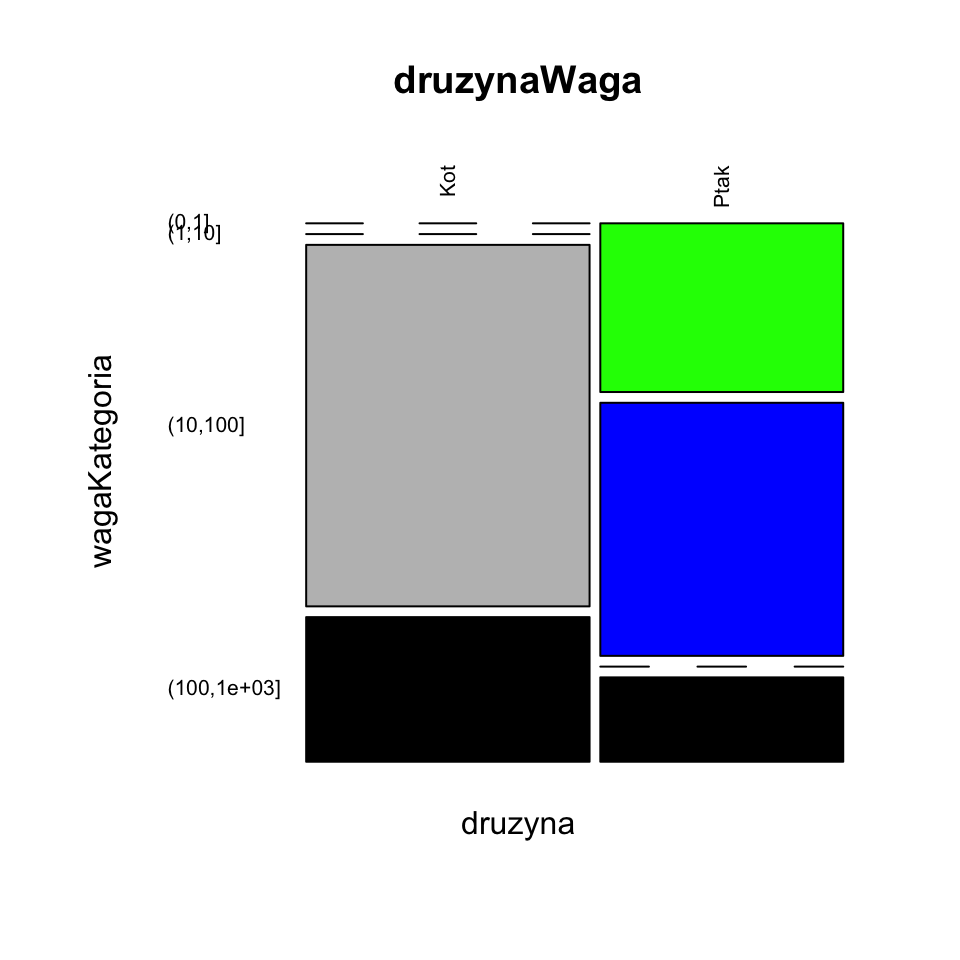

```r
mosaicplot(druzynaWaga, las=2, col=c("green", "blue", "grey", "black"))
```

# Kolejność i nazwy czynników

Domyślna kolejność czynników, to kolejność leksykograficzna. Tworząc wykresy, zazwyczaj wartości prezentowane są zgodnie z kolejnością opisaną przez atrybut `levels`.

```r
levels(auta2012$Rodzaj.paliwa)
```

```
## [1] "benzyna"                "benzyna+LPG"
## [3] "etanol"                 "hybryda"
## [5] "naped elektryczny"      "olej napedowy (diesel)"
```

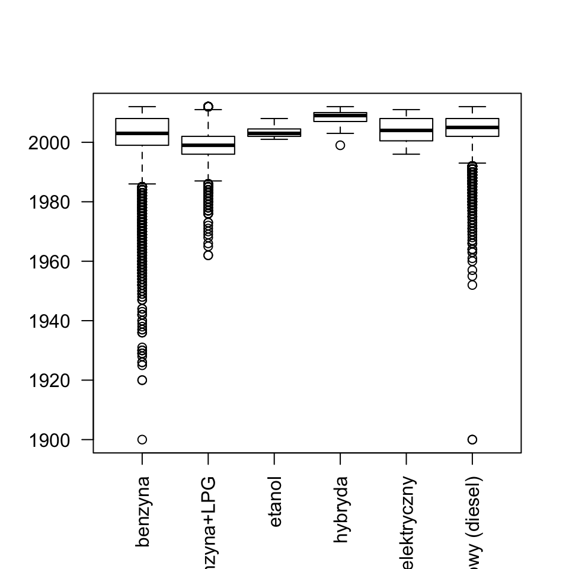

```r
boxplot(Rok.produkcji ~ Rodzaj.paliwa, auta2012, las=2)
```

# Kolejność i nazwy czynników

Domyślną kolejność można zmienić. Jednym ze sposobów określania kolejności czynników jest argument `levels` w funkcji `factor()`. Czynniki będą mieć kolejność zgodną z tam wskazaną.

```r
levels(auta2012$Skrzynia.biegow)
```

```
## [1] ""             "automatyczna" "manualna"
```

```r
auta2012$Skrzynia.biegow <- factor(auta2012$Skrzynia.biegow,
                                levels=c("manualna","", "automatyczna"))
levels(auta2012$Skrzynia.biegow)
```

```
## [1] "manualna"     ""             "automatyczna"
```

# Kolejność i nazwy czynników

Jeżeli chcemy ,,posortować’’ poziomy zgodnie z pewną cechą ilościową, to wygodne będzie użycie funkcji `reorder()`. Jako argumenty pobiera ona wektor ze zmienną czynnikową, wektor z dowolną zmienną i funkcję. Dla każdej grupy określonej przez zmienną czynnikową, dla wartości wskazanych przez drugi argument wyznaczana jest wartość funkcji - trzeciego argumentu. Następnie czynniki są porządkowane zgodnie z kolejnością wyników trzeciej funkcji.

W przykładzie poniżej, rodzaje paliwa są porządkowane zgodnie ze średnim rokiem produkcji aut o określonym rodzaju paliwa. Tak jak się można spodziewać, bardziej ,,nowoczesne’’ paliwa są w autach młodszych.

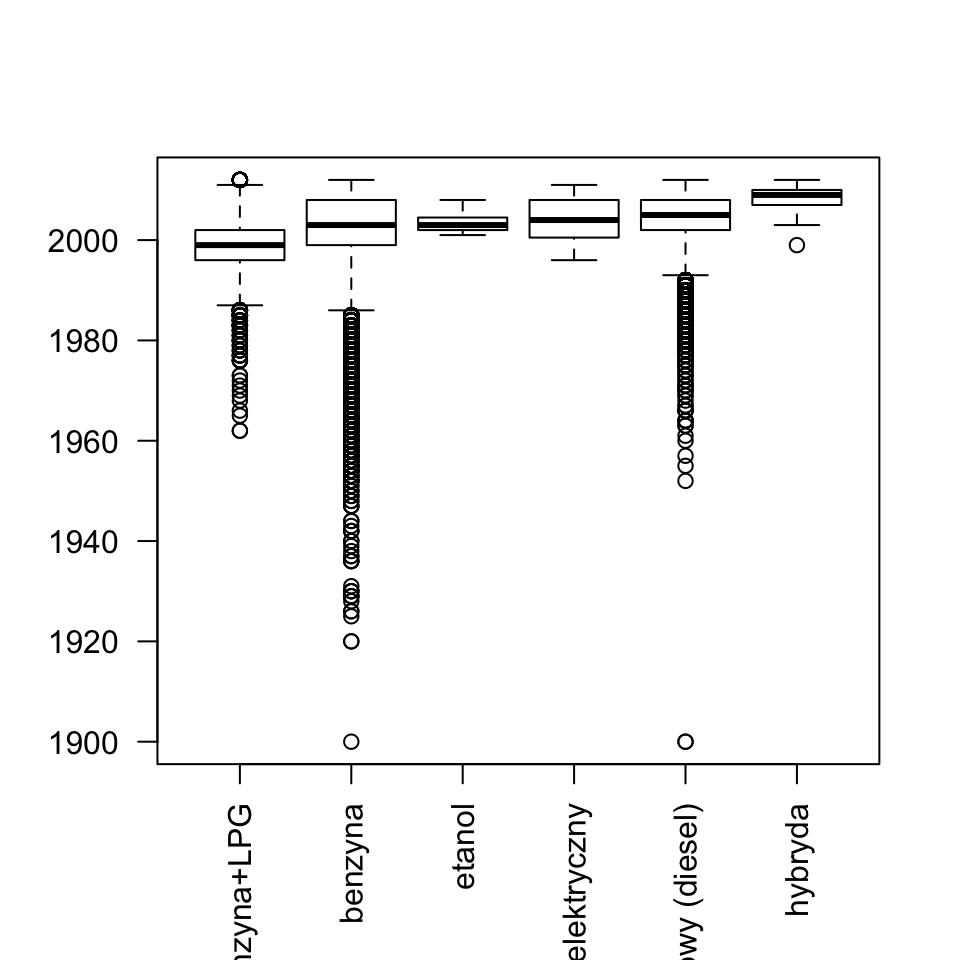

```r
auta2012$Rodzaj.paliwa.posortowany <- reorder(auta2012$Rodzaj.paliwa,
                                              auta2012$Rok.produkcji,
                                              mean)

boxplot(Rok.produkcji ~ Rodzaj.paliwa.posortowany, auta2012, las=2)
```

# Kolejność i nazwy czynników

Nazwy czynników można też dowolnie zmieniać. Najprościej można to zrobić używając funkcji `levels()` tak jak na poniższym przykładzie.

```r
levels(auta2012$Rodzaj.paliwa)
```

```
## [1] "benzyna"                "benzyna+LPG"
## [3] "etanol"                 "hybryda"
## [5] "naped elektryczny"      "olej napedowy (diesel)"
```

```r
levels(auta2012$Rodzaj.paliwa) <- c("", "B", "B+C", "B+L", "E", "H", "I", "L", "D", "W")
levels(auta2012$Rodzaj.paliwa)
```

```
##  [1] ""    "B"   "B+C" "B+L" "E"   "H"   "I"   "L"   "D"   "W"
```

# Zadania:

- W zbiorze danych `auta2012` podziel zmienne *Rok.produkcji* na przedziały 1900-1990, 1991-1995, 1996-2000, 2001-2005, 2006-2010, 2011-2012, a zmienną *Przebieg.w.km* na przedziały 0-1000, 1001-10 000, 10 001-100 000, 100 001 - 1000 000, 1000 000 - 10 000 000.
- Wyznacz tabelę liczebności dla tych dwóch nowych zmiennych.
- Przedstaw tę tabelę graficznie.

Przykładowe odpowiedzi znajdują się na stronie http://pogromcydanych.icm.edu.pl/materials/1_przetwarzanie/9_zadania.html